# P10 : Détectez des faux billets avec Python

# Définition une fuction pour tester les billets

```python
def testbillet (testdata) :
    testdata.info()

    t=testdata
    t.drop(columns=["id"],inplace=True)
    ss = StandardScaler()
    df_scaled = pd.DataFrame(ss.fit_transform(t),columns = t.columns)
    testdata['pred']=logreg.predict(df_scaled)
    testdata['probs']=logreg.predict_proba(df_scaled)[:,1]
    print(testdata.head())
```

```python
testdata=pd.read_csv(r'C:\Users\lulu\Desktop\billets_test.csv')

testbillet(testdata)
```

```
<class 'pandas.core.frame.DataFrame'>
RangeIndex: 5 entries, 0 to 4
Data columns (total 7 columns):
 #   Column        Non-Null Count  Dtype
---  ------        --------------  -----
 0   diagonal      5 non-null      float64
 1   height_left   5 non-null      float64
 2   height_right  5 non-null      float64
 3   margin_low    5 non-null      float64
 4   margin_up     5 non-null      float64
 5   length        5 non-null      float64
 6   id            5 non-null      object
dtypes: float64(6), object(1)
memory usage: 408.0+ bytes
   diagonal  height_left  height_right  margin_low  margin_up  length   pred  \
0    172.09       103.95        103.73        4.39       3.09  113.19   True
1    171.52       104.17        104.03        5.27       3.16  111.82  False
2    171.78       103.80        103.75        3.81       3.24  113.39   True
3    172.02       104.08        103.99        5.57       3.30  111.10  False
4    171.79       104.34        104.37        5.00       3.07  111.87  False

      probs
0  0.999994
1  0.006606
2  0.999986
3  0.000001
4  0.010552
```

```python
testdata=pd.read_csv(r'C:\Users\lulu\Desktop\anyone.csv')
```

```python
t=testdata
```

```python
t.drop(columns=["id"],inplace=True)
```

```python
ss = StandardScaler()
df_scaled = pd.DataFrame(ss.fit_transform(t),columns = t.columns)
```

```python
 testdata['pred']=logreg.predict(df_scaled)
```

```python
testdata
```

|  | diagonal | height_left | height_right | margin_low | margin_up | length | pred |
| --- | --- | --- | --- | --- | --- | --- | --- |
| 0 | 171.76 | 104.01 | 103.54 | 5.21 | 3.30 | 111.42 | False |
| 1 | 171.87 | 104.17 | 104.13 | 6.00 | 3.31 | 112.09 | False |
| 2 | 172.00 | 104.58 | 104.29 | 4.99 | 3.39 | 111.57 | False |
| 3 | 172.49 | 104.55 | 104.34 | 4.44 | 3.03 | 113.20 | True |
| 4 | 171.65 | 103.63 | 103.56 | 3.77 | 3.16 | 113.33 | True |

```python
 testdata['probs']=logreg.predict_proba(df_scaled)[:,1]
```

```python
testdata
```

|  | diagonal | height_left | height_right | margin_low | margin_up | length | pred | probs |
| --- | --- | --- | --- | --- | --- | --- | --- | --- |
| 0 | 171.76 | 104.01 | 103.54 | 5.21 | 3.30 | 111.42 | False | 0.023297 |
| 1 | 171.87 | 104.17 | 104.13 | 6.00 | 3.31 | 112.09 | False | 0.000221 |
| 2 | 172.00 | 104.58 | 104.29 | 4.99 | 3.39 | 111.57 | False | 0.000012 |
| 3 | 172.49 | 104.55 | 104.34 | 4.44 | 3.03 | 113.20 | True | 0.999355 |
| 4 | 171.65 | 103.63 | 103.56 | 3.77 | 3.16 | 113.33 | True | 1.000000 |

```python
t['id']=t.index
```

```python
t.head()
```

|  | diagonal | height_left | height_right | margin_low | margin_up | length | pred | probs | id |
| --- | --- | --- | --- | --- | --- | --- | --- | --- | --- |
| 0 | 171.76 | 104.01 | 103.54 | 5.21 | 3.30 | 111.42 | False | 0.023297 | 0 |
| 1 | 171.87 | 104.17 | 104.13 | 6.00 | 3.31 | 112.09 | False | 0.000221 | 1 |
| 2 | 172.00 | 104.58 | 104.29 | 4.99 | 3.39 | 111.57 | False | 0.000012 | 2 |
| 3 | 172.49 | 104.55 | 104.34 | 4.44 | 3.03 | 113.20 | True | 0.999355 | 3 |
| 4 | 171.65 | 103.63 | 103.56 | 3.77 | 3.16 | 113.33 | True | 1.000000 | 4 |

# Evaluez les performances d'un modele de machine learning

# Matrice de confusion

```python
from sklearn.model_selection import cross_val_score
clf = svm.SVC(kernel='linear', C=1, random_state=42)
scores = cross_val_score(clf, X, y, cv=5)

print((scores.mean(), scores.std()))
```

```
(0.9893333333333333, 0.004422166387140555)
```

Visualizing using Confusion Matrix

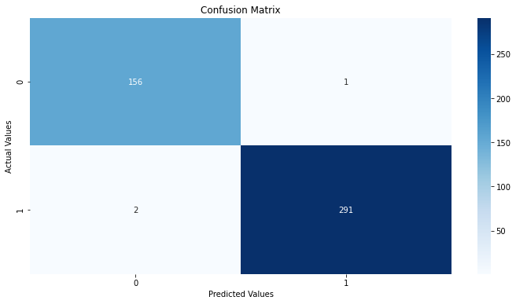

```python
cm=confusion_matrix(y_test,y_pred)
plt.figure(figsize=(12,6))
plt.title("Confusion Matrix")
sns.heatmap(cm, annot=True,fmt='d', cmap='Blues')
plt.ylabel("Actual Values")
plt.xlabel("Predicted Values")
plt.savefig('confusion_matrix.png')
```

# Évaluez un algorithme de classification qui retourne des scores

La courbe ROC

La courbe ROC permet de visualiser comment la spécificité et la sensibilité d’un modèle évolue en fonction de ce seuil.

```
roc_auc_score for DecisionTree:  0.9799786961153019
roc_auc_score for Logistic Regression:  0.9998695680528684
```

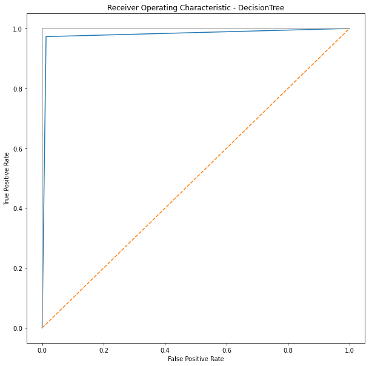

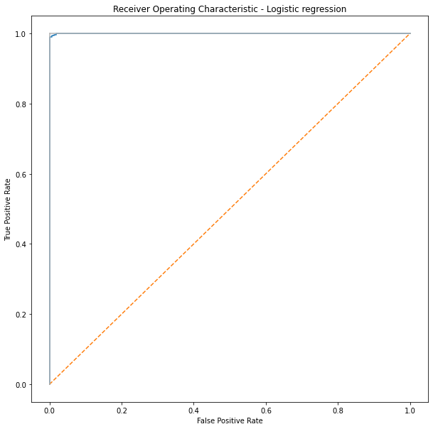

```python
    clf_tree = DecisionTreeClassifier();
    clf_reg = LogisticRegression();

    # Spliting the data and Training the model
    clf_tree.fit(X_train, y_train);
    clf_reg.fit(X_train, y_train);

    #  Using the models on test dataset

    y_score1 = clf_tree.predict_proba(X_test)[:,1]
    y_score2 = clf_reg.predict_proba(X_test)[:,1]

     # Creating False and True Positive Rates and printing Scores

    false_positive_rate1, true_positive_rate1, threshold1 = roc_curve(y_test, y_score1)
    false_positive_rate2, true_positive_rate2, threshold2 = roc_curve(y_test, y_score2)


    print('roc_auc_score for DecisionTree: ', roc_auc_score(y_test, y_score1))
    print('roc_auc_score for Logistic Regression: ', roc_auc_score(y_test, y_score2))

    # Ploting ROC Curves

    plt.subplots(1, figsize=(10,10))
    plt.title('Receiver Operating Characteristic - DecisionTree')
    plt.plot(false_positive_rate1, true_positive_rate1)
    plt.plot([0, 1], ls="--")
    plt.plot([0, 0], [1, 0] , c=".7"), plt.plot([1, 1] , c=".7")
    plt.ylabel('True Positive Rate')
    plt.xlabel('False Positive Rate')
    plt.show()

    plt.subplots(1, figsize=(10,10))
    plt.title('Receiver Operating Characteristic - Logistic regression')
    plt.plot(false_positive_rate2, true_positive_rate2)
    plt.plot([0, 1], ls="--")
    plt.plot([0, 0], [1, 0] , c=".7"), plt.plot([1, 1] , c=".7")
    plt.ylabel('True Positive Rate')
    plt.xlabel('False Positive Rate')
    plt.show()
```

ROC curve can efficiently give us the score that how our model is performing in classifing the labels. We can also plot graph between False Positive Rate and True Positive Rate with this ROC(Receiving Operating Characteristic) curve. The area under the ROC curve give is also a metric. Greater the area means better the performance.